## Máster en Data Science - Series Temporales

# Random Forest Model

Autor: Ramón Morillo Barrera

## Dataset: Madrid.csv

El modelo Random Forest es un algoritmo de aprendizaje automático basado en un conjunto de árboles de decisión, diseñado para mejorar la precisión y la robustez de las predicciones mediante el uso de múltiples árboles entrenados de manera aleatoria. Random Forest puede capturar tanto las relaciones no lineales como las interacciones complejas entre los diferentes factores que afectan la demanda de transporte. A través de un proceso de "ensamblaje", donde se promedian las predicciones de múltiples árboles para reducir el sobreajuste y aumentar la generalización, este modelo puede ser particularmente útil para manejar grandes cantidades de datos históricos con patrones estacionales, tendencias y eventos atípicos. Aunque Random Forest no es tan interpretable como un solo árbol de decisión, su capacidad para manejar datos ruidosos y su flexibilidad lo hacen adecuado para abordar la predicción de series temporales en escenarios complejos como el de los pasajeros de transporte público.

```python
# librerías
import pandas as pd
from sklearn.metrics import mean_squared_error, mean_absolute_percentage_error
from sklearn.model_selection import train_test_split
from sklearn.ensemble import RandomForestRegressor
from sklearn.metrics import r2_score
from sklearn.model_selection import GridSearchCV, RandomizedSearchCV
import matplotlib.pyplot as plt
import numpy as np
import math
import warnings

warnings.filterwarnings("ignore")
```

### Importación de datos

```python
df_autobus_month = pd.read_csv('../data/processed/Madrid_autobus_month.csv', index_col='Periodo')
df_metro_month = pd.read_csv('../data/processed/Madrid_metro_month.csv', index_col='Periodo')
df_combined_month = pd.read_csv('../data/processed/Madrid_combined_month.csv', index_col='Periodo')

df_autobus_trim = pd.read_csv('../data/processed/Madrid_autobus_trim.csv', index_col='Periodo')
df_metro_trim = pd.read_csv('../data/processed/Madrid_metro_trim.csv', index_col='Periodo')
df_combined_trim = pd.read_csv('../data/processed/Madrid_combined_trim.csv', index_col='Periodo')
```

```python
df_autobus_month = df_autobus_month[ 'Total']
df_autobus_trim = df_autobus_trim['Total']
df_combined_month = df_combined_month[ 'Total']
df_combined_trim = df_combined_trim['Total']
df_metro_month = df_metro_month['Total']
df_metro_trim = df_metro_trim['Total']
```

```python
df_autobus_month.index = pd.to_datetime(df_autobus_month.index)
df_autobus_trim.index = pd.to_datetime(df_autobus_trim.index)
df_combined_month.index = pd.to_datetime(df_combined_month.index)
df_combined_trim.index = pd.to_datetime(df_combined_trim.index)
df_metro_month.index = pd.to_datetime(df_metro_month.index)
df_metro_trim.index = pd.to_datetime(df_metro_trim.index)

df_autobus_month = df_autobus_month.resample("M").last()
df_autobus_trim = df_autobus_trim.resample("QE").last()
df_combined_month = df_combined_month.resample("M").last()
df_combined_trim = df_combined_trim.resample("QE").last()
df_metro_month = df_metro_month.resample("M").last()
df_metro_trim = df_metro_trim.resample("QE").last()
```

## Modelo Random Forest

Random Forest es un algoritmo de aprendizaje automático basado en el concepto de ensamblaje, que combina múltiples árboles de decisión para mejorar la precisión de las predicciones. En lugar de construir un solo árbol de decisión, Random Forest genera una "bosque" de árboles, entrenando cada uno con una muestra aleatoria del conjunto de datos original, seleccionando aleatoriamente un subconjunto de características para cada división en cada árbol, lo que fomenta la diversidad entre ellos. Cada árbol realiza una predicción independiente, y luego, para problemas de regresión, la predicción final se obtiene promediando las salidas de todos los árboles; para clasificación, se realiza mediante una votación mayoritaria. Este enfoque ayuda a reducir el sobreajuste, mejorar la generalización del modelo y manejar de manera efectiva datos ruidosos y no lineales, lo que lo convierte en una herramienta robusta para una variedad de tareas de predicción.

### Series mensuales

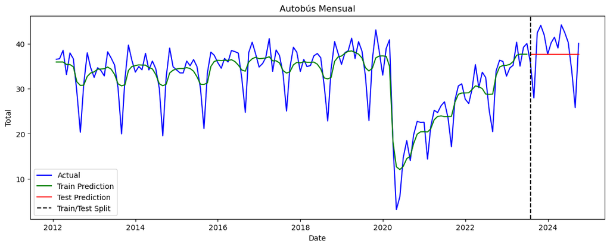

```
Best R2 Score: -0.7426571314994921
Best Parameters: {'n_estimators': 407, 'min_samples_split': 5, 'min_samples_leaf': 3, 'max_features': 3, 'max_depth': 17}
MSE: 29.02674949277614
RMSE: 5.387647862729722
MAPE: 0.12682340803514047
```

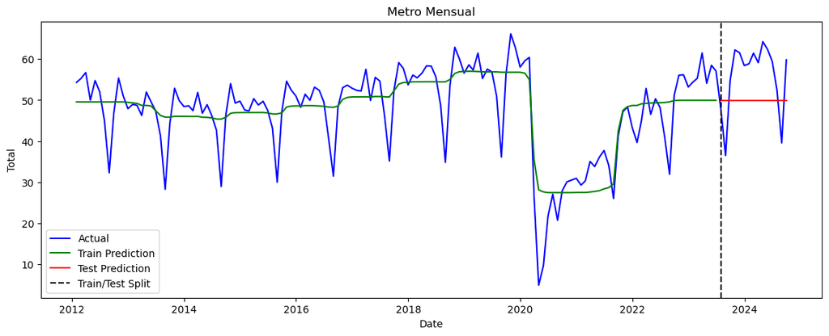

```
Best R2 Score: -0.7377688063095873
Best Parameters: {'n_estimators': 372, 'min_samples_split': 3, 'min_samples_leaf': 9, 'max_features': 61, 'max_depth': 14}
MSE: 101.426568764391
RMSE: 10.071075849401145
MAPE: 0.17209210501914238
```

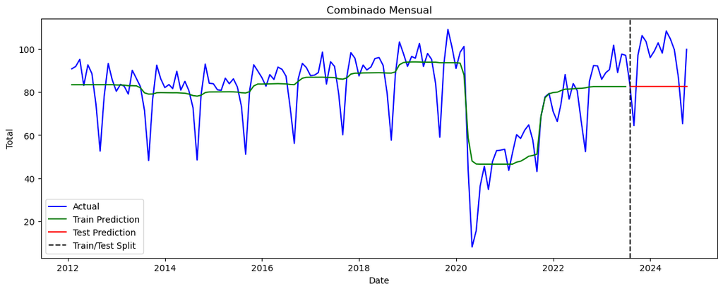

```
Best R2 Score: -0.7763274484966352
Best Parameters: {'n_estimators': 484, 'min_samples_split': 9, 'min_samples_leaf': 9, 'max_features': 87, 'max_depth': 11}
MSE: 314.8244446253461
RMSE: 17.743292947628017
MAPE: 0.1757613755885638
```

```python
# Función para entrenar, predecir y calcular métricas con RandomForest
def train_predict_plot_metrics(df, test_size, title):
    # Definir el número de observaciones para el test
    test_size = test_size

    # Crear las variables de entrenamiento y prueba
    X = np.arange(len(df)).reshape(-1, 1)
    y = df.values
    X_train, X_test, y_train, y_test = train_test_split(X, y, test_size=test_size, shuffle=False)

    # Definir el modelo y los parámetros para GridSearchCV
    model = RandomForestRegressor()
    param_distributions = {
        'n_estimators': np.random.randint(100, 500, 10),
        'max_depth': np.random.randint(10, 20, 10),
        'min_samples_split': np.random.randint(1, 10, 10),
        'min_samples_leaf': np.random.randint(1, 10, 10),
        'max_features': np.random.randint(1, 100, 10 )
    }

    # Aplicar GridSearchCV
    grid_search = RandomizedSearchCV(estimator=model, param_distributions=param_distributions, cv=5, scoring='r2')
    grid_search.fit(X_train, y_train)

    # Mejor modelo
    best_model = grid_search.best_estimator_

    # Predicciones
    y_train_pred = best_model.predict(X_train)
    y_test_pred = best_model.predict(X_test)

    # Calcular métricas
    mse = mean_squared_error(y_test, y_test_pred)
    rmse = math.sqrt(mse)
    mape = mean_absolute_percentage_error(y_test, y_test_pred)

    # Graficar
    plt.figure(figsize=(14, 5))
    plt.plot(df.index, y, label='Actual', color='blue')
    plt.plot(df.index[:len(y_train)], y_train_pred, label='Train Prediction', color='green')
    plt.plot(df.index[len(y_train):], y_test_pred, label='Test Prediction', color='red')
    plt.axvline(df.index[len(y_train)], color='black', linestyle='--', label='Train/Test Split')
    plt.title(title)
    plt.xlabel('Date')
    plt.ylabel('Total')
    plt.legend()
    plt.show()

    # Imprimir el mejor score, los mejores parámetros y las métricas
    print(f"Best R2 Score: {grid_search.best_score_}")
    print(f"Best Parameters: {grid_search.best_params_}")
    print(f"MSE: {mse}")
    print(f"RMSE: {rmse}")
    print(f"MAPE: {mape}")

# Aplicar la función a los dataframes mensuales
train_predict_plot_metrics(df_autobus_month, test_size=15, title='Autobús Mensual')
train_predict_plot_metrics(df_metro_month, test_size=15, title='Metro Mensual')
train_predict_plot_metrics(df_combined_month, test_size=15, title='Combinado Mensual')
```

### Series trimestrales

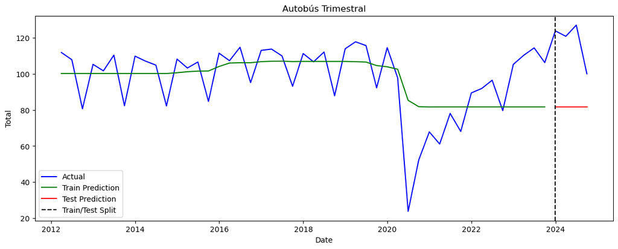

```
Best R2 Score: -0.22896686054021848
Best Parameters: {'n_estimators': 121, 'min_samples_split': 5, 'min_samples_leaf': 8, 'max_features': 87, 'max_depth': 16}
MSE: 1423.9166620627645
RMSE: 37.734820286610145
MAPE: 0.30115609832503887
```

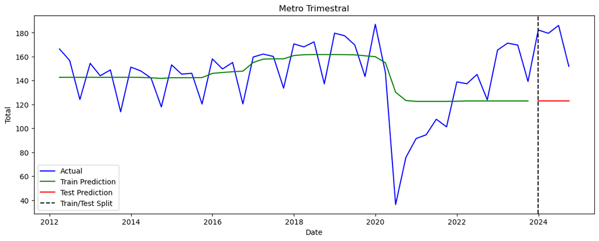

```
Best R2 Score: -0.46110250429897814
Best Parameters: {'n_estimators': 342, 'min_samples_split': 5, 'min_samples_leaf': 7, 'max_features': 86, 'max_depth': 14}
MSE: 2889.413311240419
RMSE: 53.75326326131669
MAPE: 0.2928569407712935
```

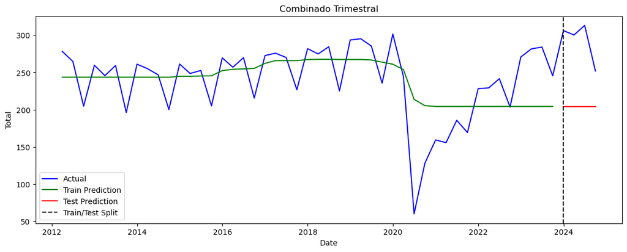

```
Best R2 Score: -0.382210799244957
Best Parameters: {'n_estimators': 264, 'min_samples_split': 9, 'min_samples_leaf': 8, 'max_features': 84, 'max_depth': 15}
MSE: 8404.067123043795
RMSE: 91.67369918926472
MAPE: 0.2969272605745285
```

```python
train_predict_plot_metrics(df_autobus_trim, test_size=4, title='Autobús Trimestral')
train_predict_plot_metrics(df_metro_trim, test_size=4, title='Metro Trimestral')
train_predict_plot_metrics(df_combined_trim, test_size=4, title='Combinado Trimestral')
```

## Conclusión Random Forest

El entrenamiento de un modelo Random Forest implica un fuerte compromiso entre la precisión de las predicciones y los costes computacionales asociados. Para obtener buenos resultados, es crucial ajustar correctamente los hiperparámetros clave, como el número de árboles (n_estimators), la profundidad máxima de los árboles (max_depth), y el número de características consideradas en cada división (max_features). Sin embargo, este proceso puede suponerun gran coste en términos de tiempo y recursos computacionales, especialmente cuando se trabaja con grandes conjuntos de datos o series temporales complejas, como la de los pasajeros de autobús y metro de Madrid. A medida que se incrementa el número de árboles o la profundidad, el modelo puede capturar mejor los patrones de los datos, pero también aumenta significativamente el tiempo de entrenamiento y el uso de memoria, lo que puede ser prohibitivo en entornos con recursos limitados.

Dado este escenario, el uso de GridSearchCV para realizar una búsqueda exhaustiva de hiperparámetros no resulta factible, ya que evalúa todas las combinaciones posibles, multiplicando exponencialmente el coste computacional. Como alternativa, he optado por usar RandomSearchCV, que realiza una búsqueda aleatoria dentro de un rango definido de hiperparámetros. Este enfoque reduce considerablemente el tiempo de cómputo al explorar solo una muestra aleatoria de combinaciones en lugar de todas, manteniendo una buena probabilidad de encontrar configuraciones cercanas al óptimo. Aunque RandomSearchCV no garantiza encontrar la mejor combinación posible, su eficiencia y balance entre precisión y coste lo convierten en una elección más práctica para el ajuste de modelos Random Forest en este contexto.